# CITS3007 lab 6 (week 8) – Binary data formats, program analysis – solutions

This lab explores

- binary data formats
- some of the [static analysis tools](https://en.wikipedia.org/wiki/Static_program_analysis) available for analysing C and C++ code
- a dynamic analysis/fuzzing tool (AFL).

# 1 Reading and writing binary data

In C programming, working with files to store and retrieve data is a fundamental task. You have already encountered **text files**, which store data as a sequence of characters, encoded in a specific character set (for instance, ASCII or UTF-8) – the `.c` and `.h` source files we use for C programming are examples of such files. Text files are also used for configuration files and many document formats, and can be opened and modified with text editors such as `vim`.

**Binary files**, on the other hand, do not (primarily) contain human-readable text. Rather, they contain data that can only be easily read or displayed using a program, including images (such as JPEG or [PNG](https://en.wikipedia.org/wiki/Portable_Network_Graphics) images), executables (which come in formats like [ELF](https://en.wikipedia.org/wiki/Executable_and_Linkable_Format), used on Linux, and [PE](https://en.wikipedia.org/wiki/Portable_Executable), used on Windows), and binary document formats (like [MS Word](https://en.wikipedia.org/wiki/Microsoft_Word) or [Adobe PDF](https://en.wikipedia.org/wiki/PDF)). They can also be used to store structured records (which, in C, we would describe and manipulate using structs). If you open a binary file with a text editor like `vim` (try opening an executable you have creating in one of the previous labs, for instance), you will see a jumble of non-human-readable characters and symbols. Unlike text files, binary files lack a clear, human-interpretable structure when viewed in a text editor – the formats they are in are optimized for efficient processing by programs, not for human readability.

When working with file formats, you will often encounter the terms “serialization” and “deserialization” (sometimes called “marshalling” and “unmarshalling”). **Serialization** refers to the process of converting complex data structures, such as objects or structs in a programming language, into a sequence of bytes that can be easily written to a (typically binary) file or transmitted over a network. The serialized data represents the original data’s structure and values in (ideally) a compact and platform-independent manner. Conversely, **deserialization** is the process of reconstructing complex data structures from the serialized binary data. The structs and formats we use in this lab (and in the project) are very simple, but complex structs could included nested structs, unions, and pointers to other structs, making the tasks of serialization and deserialization more difficult.

C has the functions the [`fread`](https://en.cppreference.com/w/c/io/fread) and [`fwrite`](https://en.cppreference.com/w/c/io/fwrite) functions for reading and writing binary data to a file. The linked cppreference.com pages show how the two functions can be used to read and write an array of `double`s. They can also be used to read and wrote whole structs.

For instance, consider the following `bank_account` struct:

```c
struct bank_account {
    int acct_num;
    char acct_name[20];
    double acct_balance;
};
```

This struct represents information about a bank account, and consists of an integer (`acct_num`) for the account number, a character array (`account_name`) to store the account holder’s name, and a floating-point number (`acct_balance`) for the account balance.

**File format complications**

Note that in a more realistic example, we [would not use a `double`](https://stackoverflow.com/questions/3730019/why-not-use-double-or-float-to-represent-currency#3730040) to represent currency. When serializing or deserializing a struct, we also would probably not use the type `int`, the size of which can vary from platform to platform. We would either amend the struct so that it uses an [exact-sized integer type](https://en.cppreference.com/w/c/types/integer) like `uint32`, or would need to cast to such a type while serializing.

Finally, we would have to account for the **endianness** of different platforms. “Endianness” refers to the byte-ordering scheme used to store multi-byte data types in RAM. In little-endian systems, the least significant byte is stored first, while in big-endian systems, the most significant byte comes first.

The x86-64 architecture uses little-endian byte ordering, which is the most common byte ordering used in processors today; examples of *big-endian* systems include the PowerPC architecture (used for some early Apple Macintosh computers) and mainframes like the IBM [Z-series](https://en.wikipedia.org/wiki/IBM_System_z). Additionally, network protocols (such as the Ethernet and [IP](https://en.wikipedia.org/wiki/Internet_Protocol) protocols) typically use big-endian byte order for data transmission (to the extent that big-endian is often referred to as “network byte order”).

What byte ordering is used in binary file formats varies – a file format could use big-endian, little-endian, or even (rarely) both in the same file. Some examples are:

- The Portable Network Graphics (PNG) format specifies a big-endian byte order for certain fields, regardless of the platform. Little-endian computers will have to do some re-ordering of bytes when reading from or writing to this format.
- The Windows Bitmap (BMP) file format used for storing bitmap images specifies little-endian byte order for various data structures within the file.

A file format could also specify that it uses the “native endianness” of the platform the file was created on, but then would not be portable between systems of different endianness.

For this laboratory (and for the project) we will assume that integer types are to be stored on disk in little-endian order. This means we can directly use the `fread` and `fwrite` functions to write integer types, without having to do any byte-reordering.

## 1.1 Writing and reading a bank account struct

Code for this lab can be found in the `lab-06-code.zip` file, and includes the following program, `write_bank_account.c`:

```c
#include <stdio.h>
#include <stdlib.h>

struct bank_account {
  int acct_num;
  char acct_name[20];
  double acct_balance;
};

int main() {
  // a bank_account instance
  struct bank_account account = {123456, "John Doe", 1000.50};

  const char * filename = "bank_account.bin";

  // open binary file for writing
  FILE *ofp = fopen(filename, "wb");

  if (ofp == NULL) {
    perror("Error opening file");
    exit(EXIT_FAILURE);
  }

  // write 'account' to file; there's 1 element to write,
  // which has size 'sizeof(struct bank_account)'.
  size_t els_written = fwrite(&account, sizeof(struct bank_account), 1, ofp);

  if (els_written != 1) {
    perror("Error writing to file");
    fclose(ofp);
    return 1;
  }

  fclose(ofp);

  printf("Bank account struct written to '%s'\n", filename);

  exit(EXIT_SUCCESS);
}
```

If we were writing an array of `bank_account` structs, the return value of `fwrite` would be the number of elements written. Here, since we have just one struct, we expect to get back the result 1; as with any C function, it’s import to always check the return value of `fwrite` to make sure an error hasn’t occurred. You can compile the program with the command:

```
$ make CC=gcc CFLAGS='-std=c11 -pedantic -Wall -Wextra -Wconversion' write_bank_account.o write_bank_account
```

Run the program; it will create a binary file named `bank_account.bin` containing the serialized `bank_account` struct. Since we can’t view binary files easily using `less` or `vim`, take a look at the contents with the program `xxd`:

```
$ xxd bank_account.bin
00000000: 40e2 0100 4a6f 686e 2044 6f65 0000 0000  @...John Doe....
00000010: 0000 0000 0000 0000 0000 0000 0044 8f40  .............D.@
```

[`xxd`](https://linux.die.net/man/1/xxd) produces a hexadecimal dump of binary files, showing both hexadecimal and ASCII representations of the data; this is handy for debugging and verifying the contents of binary files. The value 123456 is `0x0001e240` in hexadecimal notation, and we can see the first four bytes of the file contain this number in little-endian order: `40e2 0100`.

The 20 bytes after that are the string “John Doe” – in hex, “`4a6f 686e 2044 6f65`”. In the output shown above, we then see a series of zero bytes, and the last 8 bytes of the file (`0000 0000 0044 8f40`) represent the double 1000.50.

**Python for debugging and verifying binary formats**

Although our code is written in C, it can often be convenient to use Python to verify and interpret the contents of binary files.

For instance, we can use Python’s `hex()` function to get numbers in hexadecimal format. If we run `python3` to get a Python prompt, then typing `hex(123456)` at the prompt should display the result `0x1e240`, which is `0x0001e240` when padded with zeroes to 4 bytes.

We can also use the [struct](https://docs.python.org/3/library/struct.html) library to find out what the double 1000.50 looks like as a sequence of bytes.

Try the following at the Python prompt:

```
>>> import struct
>>> struct.pack('d', 1000.50).hex()
'0000000000448f40'
```

It often is also possible to perform tasks like this using the GDB debugger, which we examined in the second lab; but for many programmers, using Python will be more convenient.

The `read_bank_account.c` program contains corresponding code for reading and displaying the contents of our “`bank_account.bin`” file:

```c
#include <stdio.h>
#include <stdlib.h>

struct bank_account {
  int acct_num;
  char acct_name[20];
  double acct_balance;
};

int main() {
  // a bank_account instance to store the read data
  struct bank_account account;

  const char * filename = "bank_account.bin";

  // open the binary file for reading
  FILE *file = fopen(filename, "rb");

  if (file == NULL) {
    perror("Error opening file");
    exit(EXIT_FAILURE);
  }

  // read from the file
  size_t els_read = fread(&account, sizeof(struct bank_account), 1, file);

  if (els_read != 1) {
    perror("Error reading from file");
    fclose(file);
    exit(EXIT_FAILURE);
  }

  fclose(file);

  // display the account information
  printf("Account Number: %d\n", account.acct_num);
  printf("Account Name: %s\n", account.acct_name);
  printf("Account Balance: %.2f\n", account.acct_balance);

  return 0;
}
```

If you compile and run it, you should see displayed exactly the struct contents that we wrote in to the file.

**Exercise**

Amend the two programs so that instead of reading and writing a single struct, they read and write an array of 4 such structs. Compile and run them, and check that the output you get is what you expect.

**Exercise**

Our programs thus far both store a fixed number of records to a file (one struct in the initial `write_bank_account.c` and `read_bank_account.c` code, four structs in the code written for the previous exercise). How could we amend our programs (and the file format used) so that the file format included a count of the number of records stored?

By using these programs as examples, and reading the documentation on the cppreference.com site for `fread` and `fwrite`, you should be able to develop functions for your project which read and write in the file formats specified.

## 1.2 Struct layout, padding, and alignment

When a C compiler lays out a `struct` in memory, it does not necessarily place fields immediately adjacent to each other. Instead, it follows **alignment rules** determined by the target architecture.

Most processors are significantly more efficient when multi-byte values (such as `int`, `double`, or pointers) are stored at memory addresses that are multiples of their size (or some other platform-specific alignment boundary). To satisfy these requirements, the compiler may insert **padding bytes** between struct fields.

For example, consider:

```c
struct example {
  char c;
  int x;
};
```

Although this looks like it should only require `1 + 4 = 5` bytes, the actual layout in memory is typically:

```
offset 0:  c
offset 1–3: padding
offset 4–7: x
```

So on a typical 64-bit Linux system, `sizeof(struct example)` will usually be **8**, not 5.

Padding ensures that each field is correctly aligned in memory – `int` values are typically aligned to 4-byte boundaries, and `double` values are typically aligned to 8-byte boundaries. Misaligned accesses may be slower or, on some architectures, not supported at all.

**Alignment rules and undefined behaviour**

In C, accessing a value through a pointer that is not correctly aligned for its type can lead to **undefined behaviour (UB)**.

For example:

```c
char buffer[8];
int *p = (int *)(buffer + 1);  // potentially misaligned
int x = *p;                    // undefined behaviour in C
```

Even if this appears to “work” on some systems (notably x86-64), the behaviour is not guaranteed by the C standard. On different architectures, misaligned access may:

- work correctly but more slowly (x86/x86-64 often tolerate misalignment)
- require multiple memory operations (performance penalty), or
- trigger a hardware exception or crash (common on some ARM configurations).

## 1.3 Practical guidelines

So, what are consequences of padding for binary file formats? Because compilers are free to insert padding, the in-memory representation of a struct is not automatically a portable file format:

- `sizeof(struct)` may vary across compilers or settings.
- Field ordering is preserved, but spacing is not guaranteed.
- The in-memory layout may not match the on-disk layout.

In the `bank_account` examples in this lab, we have written a whole `bank_account` struct to disk and read it back, using calls like

```c
  size_t els_written = fwrite(&account, sizeof(struct bank_account), 1, ofp);
```

But that is only safe to do when reading and writing are both done using the same compiler, on the same platform. Different compilers and different platforms may lay the struct out differently – if you write with one compiler/platform combination, but read it back on another, you may get garbage.

To avoid issues caused by padding and alignment, it is best to treat binary file formats as a sequence of fields, not as raw memory dumps of structs. In particular:

- write each field explicitly in a defined order
- read each field explicitly in the same order
- avoid assuming that `struct` layout matches the file layout byte-for-byte

For example, instead of relying on:

```c
fwrite(&account, sizeof(struct bank_account), 1, file);
```

a more robust approach is to write individual fields:

```c
fwrite(&account.acct_num, sizeof(account.acct_num), 1, file);
fwrite(account.acct_name, sizeof(account.acct_name), 1, file);
fwrite(&account.acct_balance, sizeof(account.acct_balance), 1, file);
```

This makes the file format explicit and independent of compiler-inserted padding.

# 2 Static analysis

Static vs dynamic analysis

Recall from lectures that **static analysis tools** analyse a program for defects *without* running it, whereas **dynamic analyses** are done at runtime.

You already have experience with one sort of static analysis tool – compilers. Compilers are an example of a static analysis tool, because (in addition to producing compiled output) nearly all compilers attempt to detect one sort of defect, namely [*type errors*](https://en.wikipedia.org/wiki/Type_system#Type_errors): cases where the programmer performs operations on a data item which are not appropriate for its type. (C is sometimes referred to as [“weakly typed”](https://en.wikipedia.org/wiki/Strong_and_weak_typing) because it is possible to implicitly convert between many types – for instance, to treat unsigned integral types as signed, or vice versa.) Compilers operate on the source code of a program, but static analysis tools also exist that analyse binary artifacts (such as binary executables or libraries) – the [Ghidra](https://github.com/NationalSecurityAgency/ghidra) reverse engineering framework is an example of one of these. Compilers typically only perform a fairly limited range of checks for possible defects, so it’s often useful to augment them with other static analysis tools.

You might have already experimented with one of the key dynamic analysers we look at, too, the Google sanitizers included with GCC. These perform [dynamic analysis](https://en.wikipedia.org/wiki/Dynamic_program_analysis) of your program, and therefore require your program to be run in order to work. They operate by injecting extra instructions into your program at compile time, deliberately altering the way your program behaves. Enabling them often requires little more than adding something like “`-fsanitize=address,undefined -fno-omit-frame-pointer -g -O1`” to your GCC options.

Then, many undefined behaviours (like going out of bounds) will trigger the sanitizers to display a stack trace and an explanation of the error – making C behave much more like a language with exceptions (Python or Java, say) when it comes to trying to diagnose bugs and vulnerabilities (as opposed to its usual behaviour, which is to give no visible sign at all that something could be wrong with the program).

When completing the **unit project**, it will be up to your group to decide what static and dynamic analysis tools to use on your code in order to find defects and possible vulnerabilities.

## 2.1 Compiler options

Before looking at standalone static analysis tools, we’ll first discuss options that are already built into your compiler. It’s important to ensure you’re making good use of the features already included in GCC.

At a minimum, the compiler options you use for CITS3007 work should include the following:

```
  -std=c11 -pedantic-errors -Wall -Wextra -Wconversion
```

You can find a list of all GCC’s warning-related options [here](https://gcc.gnu.org/onlinedocs/gcc/Warning-Options.html). You can easily find recommendations for more extensive warning options than the minimum ones above by Googling for them (one set of recommendations can be found [here](https://stackoverflow.com/questions/154630/recommended-gcc-warning-options-for-c)).

Other important practices to bear in mind are:

**Compile at multiple optimization levels**

You should make sure to compile at **multiple levels** of optimization. GCC can perform **different** analyses, and thus output different warnings, depending on what level of optimization you ask it for. The `-O0` option disables all optimizations (GCC’s default behaviour), and `-O1` and `-O2` enable progressively more optimizations.

You can get documentation on all of GCC’s optimization options [here](https://gcc.gnu.org/onlinedocs/gcc/Optimize-Options.html), and obtain a brief list by running `gcc --help=optimizers`.

**Compile with and without debugging symbols**

Compiling with debug symbols enabled (GCC’s `-g` option) can **prevent** some bugs from appearing – so, even if you use debug symbols to assist you in debugging your code, it’s important to compile and test your code *without* symbols added, as well.

**Compile and test with and without sanitizers**

In later classes we will look at the sanitizers included with GCC in more detail. These perform [dynamic analysis](https://en.wikipedia.org/wiki/Dynamic_program_analysis) of your program, and therefore require your program to be run in order to work. It’s a good idea to test your code both with and without sanitizers enabled (the ASan and UBSan sanitizers are particularly effective at detecting errors).

**Compile with different compilers**

It can be helpful to try compiling your code using different compilers – although all C compilers should detect errors mandated by the C standard, what other sorts of analyses they do and the warnings they produce can vary from tool to tool. On the CITS3007 standard development environment (CDE), the GCC and Clang compilers are both available.

**Compile on different platforms**

Sometimes it can be useful to ensure your code is compiled and run on multiple platforms – for example, MacOS, Windows, and [BSD Unixes](https://en.wikipedia.org/wiki/OpenBSD), in addition to Linux. The CITS3007 project is only *required* to compile and operate correctly on Linux systems. But it can still be useful to see how it behaves on other, closely related, systems – sometimes this can expose bugs or assumptions you didn’t detect on Linux. It will be up to you to decide if this is a strategy you wish to pursue.

## 2.2 Setup

In the CITS3007 standard development environment (CDE), download the source code for the *dnstracer* program, which we’ll be analysing, and extract it:

```
$ wget http://www.mavetju.org/download/dnstracer-1.9.tar.gz
$ tar xf dnstracer-1.9.tar.gz
$ cd dnstracer-1.9
```

Dnstracer is a somewhat old piece of code – the [homepage](https://www.mavetju.org/unix/dnstracer.php) appears not have changed since 2002. It wasn’t written with the intention to conform to a particular C standard, but we’ll see if we can adapt the codebase to work with the C11 standard, issued a little under 10 years after the codebase stopped being maintained. This sort of task is not uncommon: your team may be tasked with refactoring and improving old, “legacy” code, which still seems to work, adding tests, and bringing it in line with modern standards.

Note that the Dnstracer download link is an “http” link rather than an “https” link – what problems could this cause? You can read more about Dnstracer by following the relevant links at http://www.mavetju.org/unix/general.php. It is used to graphically depict the chain of servers involved in a [Domain Name System](https://en.wikipedia.org/wiki/Domain_Name_System?useskin=vector) (DNS) query. The DNS protocol is an important part of the modern Internet, but we won’t be examining it in detail – Dnstracer is just a sample program used here to test analysis tools on.

It’s still used as a [network reconnaissance](https://medium.com/@dixitra20/network-reconnaissance-tools-1771755652c4) tool as part of penetration testing.

## 2.3 Building and analysis

### 2.3.1 Building

We will be analysing the Dsntracer program, which is subject to a known vulnerability, CVE-2017-9430. You can read more about the Dnstracer program at https://www.mavetju.org/unix/general.php.

You can build Dnstracer by running the following commands in your development environment:

```
$ ./configure
# a number of outputs of automatically run tests should appear here
$ make
# We expect this to produce many warnings and errors -- see below
```

Let’s examine what these are doing.

`./configure` and the GNU Autotools

If we want to write a C program that can be compiled and run on many systems, we need some platform-independent way of *detecting* what operating system we are running on, what tools (compilers, linkers, and scripting tools) are available, and exactly what options they support – unfortunately, these can vary widely from platform to platform.

How can we detect these things, and use that knowledge when compiling our program? One way is to use the suite of tools known as [GNU Autotools](https://en.wikipedia.org/wiki/GNU_Autotools). Rather than write a Makefile ourselves, we create a *template* for a Makefile – named `Makefile.in` – and use the GNU Autotools to create a `./configure` script which will gather details about the system it is running on, and use those details to generate:

1. a proper Makefile from the template, and
2. a `config.h` file which should be `#include`d in our C source files – this incorporates information about the system being compiled on, and defines symbols that let us know what functions and headers are available on that target system.

(Specifically, Dnstracer is using the tools [Autoconf and Automake](https://en.wikipedia.org/wiki/Autoconf) – GNU Autotools contains other tools as well which are outside the scope of this lab.)

The GNU Autotools are sometimes criticised as not being very easy to use. Alternatives to the GNU Autotools for writing platform-independent code and building on a range of platforms include the tools [Meson](https://mesonbuild.com) and [Cmake](https://cmake.org).

The `./configure` script generates two files, a `Makefile` and `config.h`, which incorporate information about the system being compiled on. However, the content of those two files is only as good as the developer makes it – if they don’t enable the compiler warnings and checks that they should, then the final executable can easily be buggy. The output of the `make` command above should show us the final compilation command being run. (Type `make clean`, then `make` again if you need to see what the output was.)

```
# Lots of output ... and eventually:
gcc -DHAVE_CONFIG_H -I. -I. -I.     -g -O2 -c `test -f 'dnstracer.c' || echo './'`dnstracer.c
```

We know from earlier classes that invoking GCC without specifying a C standard (like C11) and enabling extra warnings can easily result in code that contains bugs and security vulnerabilities – so the current version of the Makefile is insufficient for our purposes.

How can we enable extra warnings from GCC? If you run `./configure --help`, you’ll see that we can supply a number of arguments to `./configure`, and some of these are incorporated into the Makefile and use to invoke GCC. Let’s try to increase the amount of checking our compiler does (and improve error messages) by switching our compiler to `clang`, and enabling more compiler warnings:

```
$ CC=clang CFLAGS="-pedantic -Wall -Wextra" ./configure
# we expect this to produce many warnings and/or errors...
$ make clean all
```

If you look through the output, you’ll now see many warnings that include the following:

```
passing 'unsigned char *' to parameter of type 'char *' converts between pointers to integer types with different sign [-Wpointer-sign]
```

```
$ CC=clang CFLAGS="-pedantic -std=c11 -Wall -Wextra -Wno-pointer-sign" ./configure
$ make clean all
# _still_ many warnings and/or errors. but slightly fewer than before
```

The `-pedantic` flag tells the compiler to adhere strictly to the C11 standard (`-std=c11`); compilation now fails, however: the author of Dnstracer did not write properly compliant C code. In particular:

- proper `#include`s for `strncasecmp`, `strdup` and `getaddrinfo` are missing
- proper `#include`s for the `struct addrinfo` type are missing

Check `man strncasecmp`, and you’ll see it requires `#include <strings.h>`, which is missing from the C code. `man strdup` tells us that this is a Linux/POSIX function, not part of the C standard library; to inform the compiler we want to use POSIX functions, we should add a line `#define _POSIX_C_SOURCE 200809L` to our C code. This is called a *feature-test macro*. Furthermore, it’ll be useful to make use of *static asserts*, so we should include the `assert.h` header. Edit the `dnstracer.c` file, and add the following near the top of the file (e.g. just after the first block comment):

```c
#define _POSIX_C_SOURCE 200809L
#define _DEFAULT_SOURCE
#include <assert.h>
```

The `#define`s need to appear *before* we start `include`-ing header files. If we now run `make clean all`, we should have got rid of many compiler-generated warnings. But many more problems exist.

Writing portable C code – non-standard extensions to C

If we want to write portable C code – code that will work with other C compilers and/or other operating systems – it’s important to specify what *C standard* we’re wanting to adhere to (in this case, C11), and to request that the compiler strictly adhere to that standard.

When we invoke `gcc` or `clang` with the arguments “`-std=c11 -pedantic`”, this disables many compiler-specific extensions. For example: the C standard says it’s impermissible to declare a zero-length array (e.g. `int myarray[0]`), but by default, `gcc` will let you do so without warning. In general, disabling compiler-specific extensions is a good thing: it ensures we don’t accidentally use `gcc`-only features, and makes our code more portable to other compilers.

One reason some people don’t add those arguments is because (as we saw above) doing so may make their programs stop compiling. But this is because they haven’t been sufficiently careful about distinguishing between functions that are part of the [C standard library](https://en.wikipedia.org/wiki/C_standard_library), and functions which are extensions to C provided by their compiler, or are specific to the operating system they happen to be compiling on.

For example, `fopen` is part of the C standard library; if you run `man fopen`, you’ll see it’s include in the `stdio.h` header file. (And if you look under the “Conforming to” heading in the man page, you’ll see it says `POSIX.1-2001, POSIX.1-2008, C89, C99` – `fopen` is part of the C89 (and later) versions of the C standard.)

On the other hand, `strncasecmp` is *not* part of the C standard library: it was originally introduced by BSD (the “Berkeley Standard Distribution”), a previously popular flavour of Unix, and is now a GCC extension. It is part of the [POSIX standard](https://en.wikipedia.org/wiki/POSIX) for Unix-like operating systems. (If you look under the “Conforming to” heading in the man page, you’ll see it says `4.4BSD, POSIX.1-2001, POSIX.1-2008`.)

Using `-std=c11 -pedantic` encourages you to be more explicit about what compiler- or OS-specific functions you’re using. `strncasecmp` is usually only found on Unix-like operating systems. It isn’t available, for instance, when compiling on Windows with the MSVC compiler; if you want similar functionality, you need the [`_strnicmp` function](https://docs.microsoft.com/en-us/cpp/c-runtime-library/reference/strnicmp-wcsnicmp-mbsnicmp-strnicmp-l-wcsnicmp-l-mbsnicmp-l?view=msvc-170).

Sometimes when using a function from a standard other than the C standards, your compiler will require you to specify exactly what extensions and standards you want to enable. For instance, `man strdup` (rather obliquely) tells you that adding

```c
#define _POSIX_C_SOURCE 200809L
```

to your C code is one way of making the `strdup` function available.

**Note that** you should put the above `#define` **before any** `#include`s: the `#define` is called a “feature-test macro”, and it’s acting as a sort of signal to the compiler, telling it what parts of any later-appearing header files to process, and what to ignore.

Using `-std=c11 -pedantic` doesn’t *guarantee* your code conforms with the C standard (though it does help). Even with those flags enabled, it’s still quite possible to write non-conforming programs. As the [`gcc` manual says](https://gcc.gnu.org/onlinedocs/gcc/Warning-Options.html#Warning-Options):

> Some users try to use `-Wpedantic` to check programs for strict ISO C conformance. They soon find that it does not do quite what they want: it finds some non-ISO practices, but not all – only those for which ISO C requires a diagnostic, and some others for which diagnostics have been added.

From a security point of view, it’s easier to audit code that’s explicit about what libraries it’s using, than code which leaves that implicit; so specifying a C standard and `-pedantic` is usually desirable.

Project tip

Failing to use non-standard functions correctly has been a frequent source of lost marks in the unit project in previous years. If you use them, make sure you understand how to do so correctly.

### 2.3.2 Static analysis

We’ll identify some problems with Dnstracer using Flawfinder – read “How does Flawfinder Work?”, here: https://dwheeler.com/flawfinder/#how_work. Flawfinder is a linter or static analysis tool that checks for known problematic code (e.g. code that calls unsafe functions like `strcpy` and `strcat`). Install Flawfinder by running the command `sudo apt install flawfinder` in your development environment, and then try using it by running:

```
$ flawfinder *.c
```

The output typically includes a message at the end with tips on what Flawfinder’s output means. (You may get a somewhat different message at the time this lab is run.)

```
$ flawfinder *.c
# ... many lines omitted ...
Not every hit is necessarily a security vulnerability.
You can inhibit a report by adding a comment in this form:
// flawfinder: ignore
Make *sure* it's a false positive!
You can use the option --neverignore to show these.
```

In general, you’ll see a *lot* of output. This is a common problem when applying static analysis tools to an existing codebase for the first time. It’s usually preferable to start coding with static analysers already enabled – but sometimes we inherit legacy code and simply have to make do. *Commercial* static analysis companies will often provide technical experts to your organisation, as part of the process of setting the tool up, who can help configure the tool to as nearly as possible show only the warnings you want. But we are using a free and open source tool, and will have to do this job ourselves. Any good static analysis tool should allow us to *ignore* particular bits of code that would be marked problematic, either temporarily, or because we can prove to our satisfaction that the code is safe.

The output of flawfinder is not especially convenient for browsing.

It’s often more convenient to integrate the output with the editor or IDE (integrated development environment) you’re using.

You might like to see if you can find a way of integrating the output of flawfinder into your preferred editor or IDE (e.g. VS Code or Vim).

In flawfinder’s output, see if you can find mentions of “`rr_types`”. You should be able to identify that Flawfinder is giving us a general warning about *any* array with static bounds (which is, really, all arrays in C11). However, there’s another issue here – what is it?

The declared size of the array, and the number of the elements should match up; if someone changes one but not the other, that could introduce problems. We’ll add a more reliable way of checking this.

- *Remove* the size `256` from the array declaration.
- Below it, add

  ```
  static_assert(sizeof(rr_types) / sizeof(rr_types[0]) == 256,
                   "rr_types should have 256 elements");
  ```

We’re now statically checking that the number of elements in `rr_types` (i.e., the size of the array in bytes, divided by the size of one element) is always 256.

We’ll now look at warnings from a program called `clang-tidy`. It can be run from the command-line (see `man clang-tidy` for details); try running

```
$ clang-tidy --checks='-clang-diagnostic-pointer-sign' --extra-arg="-DHAVE_CONFIG_H -I. -Wno-pointer-sign" dnstracer.c --
```

(**NB**: This is a “quick and dirty” way of getting clang-tidy to run; better instructions will be provided in future weeks.)

We need to give `clang-tidy` correct compilation arguments (like `-I.`), or it won’t know where the `config.h` header is and will mis-report errors. We want it not to report problems with pointers being coerced from signed to unsigned or vice versa (i.e., the same issue flagged by `gcc` with `-Wno-pointer-sign`), so we disable that check by putting a minus in front of `clang-diagnostic-pointer-sign`.

# 3 Dynamic analysis

Let’s see how Dnstracer is supposed to be used. It will tell us the chain of [DNS name servers](https://en.wikipedia.org/wiki/Name_server) that needs to be followed to find the IP address of a host. For instance, try

```
$ ./dnstracer -4 -s ns.uwa.edu.au www.google.com
$ ./dnstracer -4 -s ns.uwa.edu.au www.arranstewart.io
```

These commands say to use a local UWA nameserver (ns.uwa.edu.au) and to follow the chain of nameservers needed to get IP addresses for two hosts (www.google.com and www.arranstewart.io). The “Google” host is fairly dull; it seems the UWA nameserver stores that IP address directly itself. The second is a little more interesting, as it requires name servers run by [Hurricane Electric](http://he.net) to be queried.

Now re-compile with `gcc` at the `O2` optimization level, and try some specially selected input:

```
$ CC=gcc CFLAGS="-pedantic -g -std=c11 -Wall -Wextra -Wno-pointer-sign -O2" ./configure
$ make clean all
$ ./dnstracer -v $(python3 -c 'print("A"*1025)')
```

You should see the message

```
*** buffer overflow detected ***: terminated
Aborted (core dumped)
```

This is the “denial of service” problem reported in CVE-2017-9430. A buffer overflow occurs, but gets caught by gcc’s inbuilt protections and causes the problem to crash. This is better than a buffer overflow being allowed to execute unchecked, but is still a problem: in general, a user should *not* be able to make a program segfault or throw an exception based on data they provide. Doing so for e.g. a server program – e.g. if a server ran code like Dnstracer’s and allowed users to provide input via, say, a web form – could result in one user being able to force the program to crash, and create a denial of service for other users. (In the present case, Dnstracer *isn’t* a server, though, so the risk is actually very minimal.)

Note that the problem doesn’t show up when compiling with `clang`, and only appears at the `O2` optimization level (which is often applied when software is being built for distribution to users). Recall that at higher optimization levels, the compiler tends to make stronger and stronger assumptions that no Undefined Behaviour ever occurs, and this can lead to vulnerabilities.

One can analyse the dumped `core` file in `gdb` to find the problematic code.

We need to run the following to ensure core dumps work properly on Ubuntu:

```
$ ulimit -c unlimited
$ sudo systemctl stop apport.service
$ sudo systemctl disable apport.service
```

ulimit and systemctl

User accounts on Linux have limits placed on things like how many files they can have open at once, and the maximum size of the stack in programs the user runs. You can see all the limits by running `ulimit -a`.

Some of these are “soft” limits which an unprivileged user can change – running `ulimit -c unlimited` says there should be no limit on the size of core files which programs run by the user may dump. Others have “hard” limits, like the number of open files. You can run `ulimit -n 2048` to change the maximum number of open files for your user to 2048, but if you try a number above that, or try running `ulimit -n unlimited`, you will get an error message:

```
bash: ulimit: open files: cannot modify limit: Operation not permitted
```

The `systemctl` command is used to start and stop system services – programs which are always running in the background. In this case, we want to stop the `apport` service: it intercepts segfaulting programs, and tries to send information about the crash to Canonical’s servers. But we don’t want that – we want to let the program crash, and we want the default behaviour for segfaulting programs, which is to produce a memory-dump in a `core` file.

Run the bad input again, and you should get a message about a core dump being generated; then run `gdb`. The commands are as follows:

```
$ ./dnstracer -v $(python3 -c 'print("A"*1025)')
$ gdb -tui ./dnstracer ./core
```

In GDB, run the commands `backtrace`, then `frame 7`: you should see that a call to `strcpy` on about line 1628 is the cause.

We’ll try to find this flaw using a particular *dynamic* analysis technique called “fuzzing”. Static analysis analyses the static artifacts of a system (like the code source files); dynamic analysis actually runs the program. We’ll use a program called `afl-fuzz`[^1] to find that bug for us, and identify input that will trigger it.

Fuzzers are very effective at finding code that can trigger program crashes, and `afl-fuzz` would normally be able to find this vulnerability (and probably many others) by itself if we just let it run for a couple of days. To speed things up, however – because in this case we already *know* what the vulnerability is – we’ll give the fuzzer some hints.

By default, `afl-fuzz` requires our program take its input from standard input (though there are ways of altering this behaviour). So to get our program working with `afl-fuzz`, we’ll add the following code at the start of `main` (search in Vim for `argv` to find it, or use the Tagbar pane and search for `main`):

```c
    int  new_argc = 2;
    char **new_argv;
    {
    new_argv = malloc(sizeof(char*) * new_argc + 1);

    // copy argv[0]
    size_t argv0_len = strlen(argv[0]);
    new_argv[0] = malloc(argv0_len + 1);
    strncpy(new_argv[0], argv[0], argv0_len);
    new_argv[argv0_len] = '\0';

    // read in argv[1] from file
    const size_t BUF_SIZE = 4096;
    char buf[BUF_SIZE];
    ssize_t res = read(0, buf, BUF_SIZE - 1);
    if (res > BUF_SIZE)
      res = BUF_SIZE;
    buf[res] = '\0';

    new_argv[1] = malloc(sizeof(char) * (res + 1));
    strncpy(new_argv[1], buf, res);
    new_argv[1][res] = '\0';

    // set argv[2] to NULL terminator
    new_argv[new_argc] = NULL;
    }

    argv = new_argv;
    argc = new_argc;
```

The aim here is to get some input from standard input, but then to ensure the input we’ve just read will work properly with the rest of the codebase (which expects to operate on arguments in `argv`).

So we create *new* versions of `argv` and `argc` (lines 1–2 of the above code), containing the data we want (obtained from standard input – line 15), and then we replace the old versions of `argv` and `argc` with our new ones (lines 28–29). If what the code is doing is not clear, try stepping through it in a debugger to see what effect each line has.

AFL requires some sample, valid inputs to work with. Run the following:

```
$ mkdir -p testcase_dir
$ printf 'www.google.com' > testcase_dir/google
$ python3 -c 'print("A"*980, end="")' > testcase_dir/manyAs
```

We also need to ideally allow afl-fuzz to *instrument* the code (i.e., insert extra instructions so it can analyze what the running code is doing) – though afl-fuzz will still work even without this step. Recompile Dnstracer by running the following:

```
$ CC=/usr/bin/afl-gcc CFLAGS="-pedantic -g -std=c11 -Wall -Wextra -Wno-pointer-sign -O2" ./configure
$ make clean all
```

Instrumenting for afl-fuzz

Some of the dynamic analysis tools we have seen (like the Google sanitizers, ASan and UBsan) are built into GCC, so to use them, we just have to supply GCC with appropriate command-line arguments (e.g. `-fsanitize=address,undefined`).

However, AFL-fuzz is not part of GCC, and it takes a different approach. It provides a command, `afl-gcc`, which behaves very similarly to normal GCC, but additionally adds in the instrumentation that AFL-fuzz needs.

So we can perform the instrumentation by specifying the option `CC=/usr/bin/afl-gcc` to the `./configure` command: this specifies a particular compiler that we want to use.

Then, to do the fuzzing, run

```
$ afl-fuzz -d -i testcase_dir -o findings_dir -- ./dnstracer
```

A “progress” screen should shortly appear, showing what AFL-fuzz is doing – something like this:

```
             american fuzzy lop ++2.59d (dnstracer) [explore] {-1}
┌─ process timing ────────────────────────────────────┬─ overall results ────┐
│        run time : 0 days, 0 hrs, 0 min, 18 sec      │  cycles done : 2     │
│   last new path : 0 days, 0 hrs, 0 min, 0 sec       │  total paths : 70    │
│ last uniq crash : none seen yet                     │ uniq crashes : 0     │
│  last uniq hang : none seen yet                     │   uniq hangs : 0     │
├─ cycle progress ───────────────────┬─ map coverage ─┴──────────────────────┤
│  now processing : 66*0 (94.3%)     │    map density : 0.02% / 0.23%        │
│ paths timed out : 0 (0.00%)        │ count coverage : 1.71 bits/tuple      │
├─ stage progress ───────────────────┼─ findings in depth ───────────────────┤
│  now trying : splice 4             │ favored paths : 26 (37.14%)           │
│ stage execs : 60/64 (93.75%)       │  new edges on : 30 (42.86%)           │
│ total execs : 58.0k                │ total crashes : 0 (0 unique)          │
│  exec speed : 3029/sec             │  total tmouts : 0 (0 unique)          │
├─ fuzzing strategy yields ──────────┴───────────────┬─ path geometry ───────┤
│   bit flips : n/a, n/a, n/a                        │    levels : 8         │
│  byte flips : n/a, n/a, n/a                        │   pending : 29        │
│ arithmetics : n/a, n/a, n/a                        │  pend fav : 0         │
│  known ints : n/a, n/a, n/a                        │ own finds : 68        │
│  dictionary : n/a, n/a, n/a                        │  imported : n/a       │
│   havoc/rad : 29/29.2k, 39/28.0k, 0/0              │ stability : 100.00%   │
│   py/custom : 0/0, 0/0                             ├───────────────────────┘
│        trim : 50.13%/169, n/a                      │             [cpu:322%]
└────────────────────────────────────────────────────┘
```

The AFL-fuzz documentation gives an explanation of this screen [here](https://github.com/google/AFL/blob/master/docs/status_screen.txt).

We’ve given afl-fuzz a *very* strong hint here about some valid input that’s *almost* invalid (`testcase_dir/manyAs`); but given time and proper configuration, many fuzzers will be able to identify such input for themselves.

After about a minute, afl-fuzz should report that it has found a “crash”; hit ctrl-c to stop it, and look in `findings_dir/crashes` for the identified bad input.

Crash files

Inside the `findings_dir/crashes` directory should be files containing input that will cause the program under test to crash. For instance, on one run of AFL-fuzz, a “bad input” file is produced called “`findings_dir/crashes/id:000000,sig:06,src:000083,time:25801+000001,op:splice,rep:16`”. The filename gives information about the crash that occurred and how the input was derived.

- “`id:000000`” is an ID for this crash – this is the first and only crash found, so the ID is 0.
- “`sig:06`” says what *signal* caused the program to crash. You can get a list of Linux signals and their numbers by running the command “`kill -L`”: signal 6 is “`SIGABRT`”, which is raised when a program calls the [`abort()`](https://man7.org/linux/man-pages/man3/abort.3.html) function. `abort()` typically gets called by the process itself; in this case, the code added by gcc to detect buffer overflows detects an overflow has occured, and “bails out” by calling `abort()`.
- “`src:000083`” isn’t too important to understand, but matches up the crash with an item in AFL-fuzz’s “queue” of inputs to try (also available under the `findings_dir`).
- “`time:25801+000001`” gives information about when the crash occurred.
- “`op:splice,rep:16`” gives information about what AFL-fuzz did to one of our inputs to get the new input that caused the crash. In this case, it performed a “splice” operation (inserting new characters into the input string) 16 times.

Since gcc’s buffer overflow protections are enabled, we should expect a crash to occur exactly when the input is long enough to overflow the buffer – at that point, gcc’s protection code detects that something has been written outside the buffer bounds, and calls `abort()`. So all AFL-fuzz has to do to trigger a crash is lengthen the input string enough. But AFL-fuzz *monitors* the code paths the program under test is executing – that’s what the “instrumentation” step is for – and can thus “learn” to explore quite complicated input structures – see [this post](https://lcamtuf.blogspot.com/2014/11/pulling-jpegs-out-of-thin-air.html) by the main developer of AFL-fuzz, Michał Zalewski, in which AFL-fuzz “learns” how to generate valid JPEG files, just from being given the input string “`hello`”.

In general, running a fuzzer on potentially vulnerable software is a pretty “cheap” activity: one can leave a fuzzer running for several days with simple, valid input, and check at the end of that period to see what problems have been discovered.

**Challenge exercise**

We’ve seen how we could have *detected* CVE-2017-9430 in advance, by letting a fuzzer generate random inputs and attempt to crash the Dnstracer program.

Can you work out the best way of fixing the problem, once detected?

# 4 Further reading on fuzzing

Take a look at *The Fuzzing Book* (by Andreas Zeller, Rahul Gopinath, Marcel Böhme, Gordon Fraser, and Christian Holler) at https://www.fuzzingbook.org, in particular the “Introduction to Fuzzing” at https://www.fuzzingbook.org/html/Fuzzer.html.

Fuzzing doesn’t apply just to C programs; the idea behind fuzzing is to randomly generate inputs in hopes of revealing crashes or other bad behaviour by a program. The *Fuzzing Book* demonstrates how the techniques by applying them to Python programs, but they are generally applicable to any language.

Fuzzing has been very successful at finding security vulnerabilities in software – often much more so than writing unit tests, for instance. An issue with unit tests is that human testers can’t generate as *many* tests as a fuzzer can (fuzzers will often generate at least thousands per second), and often have trouble coming up with test inputs that are sufficiently “off the beaten path” of normal program execution to trigger vulnerabilities.

Fuzzers often work well with some of the dynamic *sanitizers* which we’ve seen `gcc` and `clang` provide. The sanitizers (such as ASAN, the AddressSanitizer, and UBSan, the [Undefined Behaviour sanitizer](https://clang.llvm.org/docs/UndefinedBehaviorSanitizer.html)) help with making a program *crash* if memory-access problems or undefined behaviour are detected.

You can read more about AFL-fuzz at https://afl-1.readthedocs.io/en/latest/fuzzing.html, and if you have time, experiment with the `honggfuzz` fuzzer (https://github.com/google/honggfuzz) or using AFL-fuzz in combination with sanitizers.

# 5 Other tools

This lab introduces several static analysis tools – but these should not be the only tools you use to analyse your code. In practice, different tools will detect different possible defects, so it’s important to use a **range** of tools to reduce the chances of defects creeping into your code.

It’s therefore recommended your group try other static analysis tools to see what benefit they provide. Some suggested tools include:

**[**Cppcheck**](https://cppcheck.sourceforge.io)**

Cppcheck aims to have a low false-positive rate, and performs what is called “flow analysis” – it can detect when a construct in your code could cause problems later (or earlier) in the program.

**[**Clang static analyzer**](https://clang-analyzer.llvm.org)**

This is a different tool to clang-tidy – the Clang project has a number of distinct static analysis tools associated with it. The clang static analyser not only performs extensive static analysis of your code, but is capable of describing the problems using easy-to-understand diagrams produced from your code, like this one:

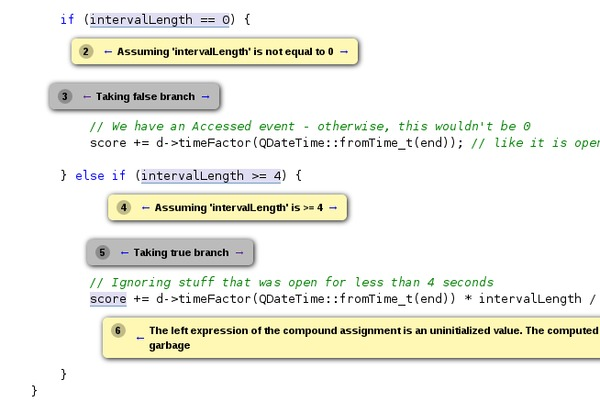

The simplest way to run the static analyser is usually [from the command-line](https://clang.llvm.org/docs/analyzer/user-docs/CommandLineUsage.html), with the `scan-build` command.

[**Sparse**](https://sparse.docs.kernel.org/en/latest/)

This tool is used for analysing the Linux kernel source code – it can catch mismatched types, implicit casts, and other type-related bugs that the compiler may not warn about. It supports the use of [*annotations* on the code](https://gcc.gnu.org/onlinedocs/gcc/Function-Attributes.html) which can help the compiler and analyser more clearly understand the intent of your code.

[**Ikos**](https://github.com/NASA-SW-VnV/ikos/)

Developed by NASA, Ikos performs what is called *abstract interpretation* on a program – a static analysis technique that approximates the set of all possible paths through the program, and what state the program would be in at each point.

[^1]: “AFL” stands for “American Fuzzy Lop”, a type of rabbit; `afl-fuzz` was developed by Google. Read about it further at https://github.com/google/AFL. (If you have time, you might like to try using another fuzzer, `honggfuzz`, by reading the documentation at https://github.com/google/honggfuzz.)